# ANCOVA in Vocabulario Ensinado (Vocabulario Ensinado)

Geiser C. Challco geiser@alumni.usp.br

- Descriptive Statistics of Initial Data
- ANCOVA and Pairwise for one factor: **grupo**
  - Without remove non-normal data
  - Computing ANCOVA and PairWise After removing non-normal data (OK)
    - Plots for ancova
    - Checking linearity assumption
    - Checking normality and homogeneity
- ANCOVA and Pairwise for two factors **grupo:Sexo**
  - Without remove non-normal data
  - Computing ANCOVA and PairWise After removing non-normal data (OK)
    - Plots for ancova
    - Checking linearity assumption
    - Checking normality and homogeneity
- ANCOVA and Pairwise for two factors **grupo:Zona**
  - Without remove non-normal data
  - Computing ANCOVA and PairWise After removing non-normal data (OK)
    - Plots for ancova
    - Checking linearity assumption
    - Checking normality and homogeneity
- ANCOVA and Pairwise for two factors **grupo:Cor.Raca**
  - Without remove non-normal data
  - Computing ANCOVA and PairWise After removing non-normal data (OK)
    - Plots for ancova
    - Checking linearity assumption
    - Checking normality and homogeneity
- ANCOVA and Pairwise for two factors **grupo:vocab.teach.quintile**
  - Without remove non-normal data
  - Computing ANCOVA and PairWise After removing non-normal data (OK)
    - Plots for ancova
    - Checking linearity assumption
    - Checking normality and homogeneity
- Summary of Results
  - Descriptive Statistics
  - ANCOVA Table Comparison
  - PairWise Table Comparison
  - EMMS Table Comparison

**NOTE**:

- Teste ANCOVA para determinar se houve diferenças significativas no Vocabulario Ensinado (medido usando pre- e pos-testes).
- ANCOVA test to determine whether there were significant differences in Vocabulario Ensinado (measured using pre- and post-tests).

# Descriptive Statistics of Initial Data

```r
df <- get.descriptives(dat, c(dv.pre, dv.pos), c("grupo"),
                       include.global = T, symmetry.test = T, normality.test = F)
df <- plyr::rbind.fill(
  df, do.call(plyr::rbind.fill, lapply(lfatores2, FUN = function(f) {
    if (nrow(dat) > 0 && sum(!is.na(unique(dat[[f]]))) > 1)
      get.descriptives(dat, c(dv.pre,dv.pos), c("grupo", f),
                       symmetry.test = T, normality.test = F)
    }))
)
(df <- df[,c(fatores1[fatores1 %in% colnames(df)],"variable",
             colnames(df)[!colnames(df) %in% c(fatores1,"variable")])])
```

```
##           grupo Sexo   Zona Cor.Raca vocab.teach.quintile        variable   n  mean median min max    sd    se
## 1      Controle <NA>   <NA>     <NA>                 <NA> vocab.teach.pre 146 3.925    4.0   0  10 1.901 0.157
## 2  Experimental <NA>   <NA>     <NA>                 <NA> vocab.teach.pre 165 4.255    4.0   1  11 1.902 0.148
## 3          <NA> <NA>   <NA>     <NA>                 <NA> vocab.teach.pre 311 4.100    4.0   0  11 1.906 0.108
## 4      Controle <NA>   <NA>     <NA>                 <NA> vocab.teach.pos 146 4.158    4.0   0   9 1.957 0.162
## 5  Experimental <NA>   <NA>     <NA>                 <NA> vocab.teach.pos 165 5.164    5.0   0  11 2.346 0.183
## 6          <NA> <NA>   <NA>     <NA>                 <NA> vocab.teach.pos 311 4.691    5.0   0  11 2.226 0.126
## 7      Controle    F   <NA>     <NA>                 <NA> vocab.teach.pre  65 4.062    4.0   0   9 1.870 0.232
## 8      Controle    M   <NA>     <NA>                 <NA> vocab.teach.pre  81 3.815    3.0   0  10 1.931 0.215
## 9  Experimental    F   <NA>     <NA>                 <NA> vocab.teach.pre  88 4.284    4.0   1  10 1.929 0.206
## 10 Experimental    M   <NA>     <NA>                 <NA> vocab.teach.pre  77 4.221    4.0   1  11 1.882 0.214
## 11     Controle    F   <NA>     <NA>                 <NA> vocab.teach.pos  65 4.462    4.0   0   9 1.985 0.246
## 12     Controle    M   <NA>     <NA>                 <NA> vocab.teach.pos  81 3.914    4.0   0   9 1.912 0.212
## 13 Experimental    F   <NA>     <NA>                 <NA> vocab.teach.pos  88 5.534    6.0   0  11 2.207 0.235
## 14 Experimental    M   <NA>     <NA>                 <NA> vocab.teach.pos  77 4.740    4.0   1  10 2.441 0.278
```

[output cut: 98 more lines]

| grupo | Sexo | Zona | Cor.Raca | vocab.teach.quintile | variable | n | mean | median | min | max | sd | se | ci | iqr | symmetry | skewness | kurtosis |
| --- | --- | --- | --- | --- | --- | --- | --- | --- | --- | --- | --- | --- | --- | --- | --- | --- | --- |
| Controle |  |  |  |  | vocab.teach.pre | 146 | 3.925 | 4.0 | 0 | 10 | 1.901 | 0.157 | 0.311 | 3.00 | YES | 0.418 | -0.039 |
| Experimental |  |  |  |  | vocab.teach.pre | 165 | 4.255 | 4.0 | 1 | 11 | 1.902 | 0.148 | 0.292 | 2.00 | NO | 0.618 | 0.553 |
|  |  |  |  |  | vocab.teach.pre | 311 | 4.100 | 4.0 | 0 | 11 | 1.906 | 0.108 | 0.213 | 2.00 | NO | 0.521 | 0.326 |
| Controle |  |  |  |  | vocab.teach.pos | 146 | 4.158 | 4.0 | 0 | 9 | 1.957 | 0.162 | 0.320 | 3.00 | YES | 0.170 | -0.451 |
| Experimental |  |  |  |  | vocab.teach.pos | 165 | 5.164 | 5.0 | 0 | 11 | 2.346 | 0.183 | 0.361 | 4.00 | YES | 0.244 | -0.620 |
|  |  |  |  |  | vocab.teach.pos | 311 | 4.691 | 5.0 | 0 | 11 | 2.226 | 0.126 | 0.248 | 3.00 | YES | 0.318 | -0.367 |
| Controle | F |  |  |  | vocab.teach.pre | 65 | 4.062 | 4.0 | 0 | 9 | 1.870 | 0.232 | 0.463 | 2.00 | YES | 0.152 | -0.132 |
| Controle | M |  |  |  | vocab.teach.pre | 81 | 3.815 | 3.0 | 0 | 10 | 1.931 | 0.215 | 0.427 | 3.00 | NO | 0.620 | 0.062 |
| Experimental | F |  |  |  | vocab.teach.pre | 88 | 4.284 | 4.0 | 1 | 10 | 1.929 | 0.206 | 0.409 | 3.00 | YES | 0.312 | -0.237 |
| Experimental | M |  |  |  | vocab.teach.pre | 77 | 4.221 | 4.0 | 1 | 11 | 1.882 | 0.214 | 0.427 | 2.00 | NO | 0.981 | 1.496 |
| Controle | F |  |  |  | vocab.teach.pos | 65 | 4.462 | 4.0 | 0 | 9 | 1.985 | 0.246 | 0.492 | 3.00 | YES | -0.003 | -0.368 |
| Controle | M |  |  |  | vocab.teach.pos | 81 | 3.914 | 4.0 | 0 | 9 | 1.912 | 0.212 | 0.423 | 2.00 | YES | 0.302 | -0.480 |
| Experimental | F |  |  |  | vocab.teach.pos | 88 | 5.534 | 6.0 | 0 | 11 | 2.207 | 0.235 | 0.468 | 3.00 | YES | -0.036 | -0.482 |
| Experimental | M |  |  |  | vocab.teach.pos | 77 | 4.740 | 4.0 | 1 | 10 | 2.441 | 0.278 | 0.554 | 3.00 | NO | 0.588 | -0.454 |
| Controle |  | Rural |  |  | vocab.teach.pre | 97 | 4.072 | 4.0 | 0 | 10 | 2.032 | 0.206 | 0.410 | 3.00 | YES | 0.331 | -0.233 |
| Controle |  | Urbana |  |  | vocab.teach.pre | 28 | 3.964 | 4.0 | 0 | 8 | 1.795 | 0.339 | 0.696 | 2.00 | YES | 0.126 | -0.462 |
| Controle |  |  |  |  | vocab.teach.pre | 21 | 3.190 | 3.0 | 2 | 5 | 1.167 | 0.255 | 0.531 | 2.00 | YES | 0.368 | -1.442 |
| Experimental |  | Rural |  |  | vocab.teach.pre | 85 | 4.129 | 4.0 | 1 | 11 | 1.993 | 0.216 | 0.430 | 3.00 | NO | 0.698 | 0.535 |
| Experimental |  | Urbana |  |  | vocab.teach.pre | 38 | 4.395 | 4.0 | 1 | 9 | 2.034 | 0.330 | 0.669 | 2.00 | YES | 0.317 | -0.511 |
| Experimental |  |  |  |  | vocab.teach.pre | 42 | 4.381 | 4.0 | 1 | 10 | 1.592 | 0.246 | 0.496 | 1.75 | NO | 0.903 | 2.033 |
| Controle |  | Rural |  |  | vocab.teach.pos | 97 | 4.186 | 4.0 | 0 | 9 | 1.970 | 0.200 | 0.397 | 3.00 | YES | 0.350 | -0.243 |
| Controle |  | Urbana |  |  | vocab.teach.pos | 28 | 4.536 | 5.0 | 1 | 7 | 1.856 | 0.351 | 0.720 | 3.00 | YES | -0.339 | -1.022 |
| Controle |  |  |  |  | vocab.teach.pos | 21 | 3.524 | 3.0 | 0 | 7 | 1.965 | 0.429 | 0.895 | 3.00 | YES | 0.004 | -1.196 |
| Experimental |  | Rural |  |  | vocab.teach.pos | 85 | 5.000 | 5.0 | 0 | 10 | 2.304 | 0.250 | 0.497 | 4.00 | YES | 0.063 | -0.816 |
| Experimental |  | Urbana |  |  | vocab.teach.pos | 38 | 5.342 | 5.0 | 1 | 10 | 2.386 | 0.387 | 0.784 | 3.75 | YES | 0.313 | -0.892 |
| Experimental |  |  |  |  | vocab.teach.pos | 42 | 5.333 | 5.0 | 2 | 11 | 2.426 | 0.374 | 0.756 | 3.75 | YES | 0.459 | -0.489 |
| Controle |  |  | Branca |  | vocab.teach.pre | 22 | 3.773 | 3.5 | 1 | 8 | 1.875 | 0.400 | 0.832 | 3.00 | YES | 0.314 | -0.893 |
| Controle |  |  | Indígena |  | vocab.teach.pre | 2 | 5.500 | 5.5 | 5 | 6 | 0.707 | 0.500 | 6.353 | 0.50 | few data | 0.000 | 0.000 |
| Controle |  |  | Parda |  | vocab.teach.pre | 42 | 3.976 | 4.0 | 0 | 10 | 2.181 | 0.336 | 0.680 | 3.00 | YES | 0.470 | 0.257 |
| Controle |  |  | Preta |  | vocab.teach.pre | 1 | 3.000 | 3.0 | 3 | 3 |  |  |  | 0.00 | few data | 0.000 | 0.000 |
| Controle |  |  |  |  | vocab.teach.pre | 79 | 3.911 | 4.0 | 0 | 8 | 1.784 | 0.201 | 0.400 | 2.50 | YES | 0.386 | -0.575 |
| Experimental |  |  | Branca |  | vocab.teach.pre | 18 | 4.722 | 5.0 | 2 | 8 | 1.873 | 0.441 | 0.931 | 2.00 | YES | -0.126 | -1.190 |
| Experimental |  |  | Indígena |  | vocab.teach.pre | 13 | 4.000 | 4.0 | 2 | 6 | 1.414 | 0.392 | 0.855 | 2.00 | YES | -0.163 | -1.385 |
| Experimental |  |  | Parda |  | vocab.teach.pre | 44 | 3.864 | 4.0 | 1 | 9 | 1.837 | 0.277 | 0.559 | 2.25 | YES | 0.460 | -0.164 |
| Experimental |  |  | Preta |  | vocab.teach.pre | 1 | 1.000 | 1.0 | 1 | 1 |  |  |  | 0.00 | few data | 0.000 | 0.000 |
| Experimental |  |  |  |  | vocab.teach.pre | 89 | 4.427 | 4.0 | 1 | 11 | 1.965 | 0.208 | 0.414 | 2.00 | NO | 0.832 | 0.921 |
| Controle |  |  | Branca |  | vocab.teach.pos | 22 | 4.273 | 4.0 | 1 | 9 | 2.334 | 0.498 | 1.035 | 3.50 | YES | 0.286 | -1.011 |
| Controle |  |  | Indígena |  | vocab.teach.pos | 2 | 6.000 | 6.0 | 5 | 7 | 1.414 | 1.000 | 12.706 | 1.00 | few data | 0.000 | 0.000 |
| Controle |  |  | Parda |  | vocab.teach.pos | 42 | 4.238 | 4.0 | 0 | 9 | 2.093 | 0.323 | 0.652 | 3.00 | YES | 0.050 | -0.476 |
| Controle |  |  | Preta |  | vocab.teach.pos | 1 | 6.000 | 6.0 | 6 | 6 |  |  |  | 0.00 | few data | 0.000 | 0.000 |
| Controle |  |  |  |  | vocab.teach.pos | 79 | 4.013 | 4.0 | 0 | 9 | 1.779 | 0.200 | 0.399 | 2.00 | YES | 0.183 | -0.467 |
| Experimental |  |  | Branca |  | vocab.teach.pos | 18 | 4.611 | 4.5 | 1 | 9 | 2.477 | 0.584 | 1.232 | 4.75 | YES | 0.094 | -1.630 |
| Experimental |  |  | Indígena |  | vocab.teach.pos | 13 | 4.769 | 5.0 | 2 | 9 | 2.048 | 0.568 | 1.237 | 2.00 | YES | 0.394 | -0.779 |
| Experimental |  |  | Parda |  | vocab.teach.pos | 44 | 4.932 | 5.0 | 1 | 10 | 2.204 | 0.332 | 0.670 | 4.00 | YES | 0.148 | -0.854 |
| Experimental |  |  | Preta |  | vocab.teach.pos | 1 | 4.000 | 4.0 | 4 | 4 |  |  |  | 0.00 | few data | 0.000 | 0.000 |
| Experimental |  |  |  |  | vocab.teach.pos | 89 | 5.461 | 5.0 | 0 | 11 | 2.431 | 0.258 | 0.512 | 4.00 | YES | 0.233 | -0.593 |
| Controle |  |  |  | 1st quintile | vocab.teach.pre | 40 | 1.700 | 2.0 | 0 | 2 | 0.608 | 0.096 | 0.194 | 0.00 | few data | 0.000 | 0.000 |
| Controle |  |  |  | 2nd quintile | vocab.teach.pre | 25 | 3.000 | 3.0 | 3 | 3 | 0.000 | 0.000 | 0.000 | 0.00 | few data | 0.000 | 0.000 |
| Controle |  |  |  | 3rd quintile | vocab.teach.pre | 54 | 4.556 | 5.0 | 4 | 5 | 0.502 | 0.068 | 0.137 | 1.00 | few data | 0.000 | 0.000 |
| Controle |  |  |  | 4th quintile | vocab.teach.pre | 14 | 6.000 | 6.0 | 6 | 6 | 0.000 | 0.000 | 0.000 | 0.00 | few data | 0.000 | 0.000 |
| Controle |  |  |  | 5th quintile | vocab.teach.pre | 13 | 7.692 | 7.0 | 7 | 10 | 0.947 | 0.263 | 0.572 | 1.00 | NO | 1.115 | 0.145 |
| Experimental |  |  |  | 1st quintile | vocab.teach.pre | 33 | 1.758 | 2.0 | 1 | 2 | 0.435 | 0.076 | 0.154 | 0.00 | few data | 0.000 | 0.000 |
| Experimental |  |  |  | 2nd quintile | vocab.teach.pre | 23 | 3.000 | 3.0 | 3 | 3 | 0.000 | 0.000 | 0.000 | 0.00 | few data | 0.000 | 0.000 |
| Experimental |  |  |  | 3rd quintile | vocab.teach.pre | 72 | 4.417 | 4.0 | 4 | 5 | 0.496 | 0.059 | 0.117 | 1.00 | few data | 0.000 | 0.000 |
| Experimental |  |  |  | 4th quintile | vocab.teach.pre | 18 | 6.000 | 6.0 | 6 | 6 | 0.000 | 0.000 | 0.000 | 0.00 | few data | 0.000 | 0.000 |
| Experimental |  |  |  | 5th quintile | vocab.teach.pre | 19 | 7.842 | 7.0 | 7 | 11 | 1.214 | 0.279 | 0.585 | 1.50 | NO | 1.166 | 0.200 |
| Controle |  |  |  | 1st quintile | vocab.teach.pos | 40 | 3.550 | 3.5 | 0 | 7 | 1.797 | 0.284 | 0.575 | 3.00 | YES | 0.024 | -0.693 |
| Controle |  |  |  | 2nd quintile | vocab.teach.pos | 25 | 3.480 | 3.0 | 0 | 6 | 1.636 | 0.327 | 0.675 | 3.00 | YES | 0.007 | -0.842 |
| Controle |  |  |  | 3rd quintile | vocab.teach.pos | 54 | 4.167 | 4.0 | 1 | 9 | 1.921 | 0.261 | 0.524 | 2.00 | YES | 0.332 | -0.180 |
| Controle |  |  |  | 4th quintile | vocab.teach.pos | 14 | 5.571 | 5.5 | 3 | 8 | 1.697 | 0.453 | 0.980 | 2.00 | YES | -0.333 | -1.387 |
| Controle |  |  |  | 5th quintile | vocab.teach.pos | 13 | 5.769 | 6.0 | 2 | 9 | 1.922 | 0.533 | 1.161 | 3.00 | YES | -0.219 | -0.900 |
| Experimental |  |  |  | 1st quintile | vocab.teach.pos | 33 | 4.242 | 3.0 | 1 | 10 | 2.278 | 0.397 | 0.808 | 3.00 | YES | 0.463 | -0.684 |
| Experimental |  |  |  | 2nd quintile | vocab.teach.pos | 23 | 5.087 | 5.0 | 2 | 8 | 1.676 | 0.350 | 0.725 | 2.50 | YES | -0.075 | -1.271 |
| Experimental |  |  |  | 3rd quintile | vocab.teach.pos | 72 | 5.000 | 5.0 | 2 | 11 | 2.283 | 0.269 | 0.536 | 4.00 | NO | 0.560 | -0.405 |
| Experimental |  |  |  | 4th quintile | vocab.teach.pos | 18 | 5.556 | 6.0 | 0 | 9 | 2.684 | 0.633 | 1.335 | 3.00 | YES | -0.498 | -0.819 |
| Experimental |  |  |  | 5th quintile | vocab.teach.pos | 19 | 7.105 | 7.0 | 3 | 10 | 2.079 | 0.477 | 1.002 | 2.50 | YES | -0.097 | -0.983 |

# ANCOVA and Pairwise for one factor: **grupo**

## Without remove non-normal data

```r
pdat = remove_group_data(dat[!is.na(dat[["grupo"]]),], "vocab.teach.pos", "grupo")

pdat.long <- rbind(pdat[,c("id","grupo")], pdat[,c("id","grupo")])
pdat.long[["time"]] <- c(rep("pre", nrow(pdat)), rep("pos", nrow(pdat)))
pdat.long[["time"]] <- factor(pdat.long[["time"]], c("pre","pos"))
pdat.long[["vocab.teach"]] <- c(pdat[["vocab.teach.pre"]], pdat[["vocab.teach.pos"]])

aov = anova_test(pdat, vocab.teach.pos ~ vocab.teach.pre + grupo)
laov[["grupo"]] <- get_anova_table(aov)
```

```r
pwc <- emmeans_test(pdat, vocab.teach.pos ~ grupo, covariate = vocab.teach.pre,
                    p.adjust.method = "bonferroni")
```

```r
pwc.long <- emmeans_test(dplyr::group_by_at(pdat.long, "grupo"),
                          vocab.teach ~ time,
                          p.adjust.method = "bonferroni")
lpwc[["grupo"]] <- plyr::rbind.fill(pwc, pwc.long)
```

```r
ds <- get.descriptives(pdat, "vocab.teach.pos", "grupo", covar = "vocab.teach.pre")
ds <- merge(ds[ds$variable != "vocab.teach.pre",],
            ds[ds$variable == "vocab.teach.pre", !colnames(ds) %in% c("variable")],
            by = "grupo", all.x = T, suffixes = c("", ".vocab.teach.pre"))
ds <- merge(get_emmeans(pwc), ds, by = "grupo", suffixes = c(".emms", ""))
ds <- ds[,c("grupo","n","mean.vocab.teach.pre","se.vocab.teach.pre","mean","se","emmean","se.emms")]

colnames(ds) <- c("grupo", "N", paste0(c("M","SE")," (pre)"),
                  paste0(c("M","SE"), " (unadj)"), paste0(c("M", "SE"), " (adj)"))

lemms[["grupo"]] <- ds
```

## Computing ANCOVA and PairWise After removing non-normal data (OK)

```r
wdat = pdat

res = residuals(lm(vocab.teach.pos ~ vocab.teach.pre + grupo, data = wdat))
non.normal = getNonNormal(res, wdat$id, plimit = 0.05)

wdat = wdat[!wdat$id %in% non.normal,]

wdat.long <- rbind(wdat[,c("id","grupo")], wdat[,c("id","grupo")])
wdat.long[["time"]] <- c(rep("pre", nrow(wdat)), rep("pos", nrow(wdat)))
wdat.long[["time"]] <- factor(wdat.long[["time"]], c("pre","pos"))
wdat.long[["vocab.teach"]] <- c(wdat[["vocab.teach.pre"]], wdat[["vocab.teach.pos"]])

ldat[["grupo"]] = wdat

(non.normal)
```

```r
aov = anova_test(wdat, vocab.teach.pos ~ vocab.teach.pre + grupo)
laov[["grupo"]] <- merge(get_anova_table(aov), laov[["grupo"]], by="Effect", suffixes = c("","'"))

(df = get_anova_table(aov))
```

```
## ANOVA Table (type II tests)
##
##            Effect DFn DFd      F        p p<.05   ges
## 1 vocab.teach.pre   1 308 37.169 3.24e-09     * 0.108
## 2           grupo   1 308 14.174 2.00e-04     * 0.044
```

| Effect | DFn | DFd | F | p | p<.05 | ges |
| --- | --- | --- | --- | --- | --- | --- |
| vocab.teach.pre | 1 | 308 | 37.169 | 0 | * | 0.108 |
| grupo | 1 | 308 | 14.174 | 0 | * | 0.044 |

| term | .y. | group1 | group2 | df | statistic | p | p.adj | p.adj.signif |
| --- | --- | --- | --- | --- | --- | --- | --- | --- |
| vocab.teach.pre*grupo | vocab.teach.pos | Controle | Experimental | 308 | -3.765 | 0 | 0 | *** |

```r
pwc.long <- emmeans_test(dplyr::group_by_at(wdat.long, "grupo"),
                         vocab.teach ~ time,
                         p.adjust.method = "bonferroni")
lpwc[["grupo"]] <- merge(plyr::rbind.fill(pwc, pwc.long), lpwc[["grupo"]], by=c("grupo","term",".y.","group1","group2"), suffixes = c("","'"))
```

| grupo | term | .y. | group1 | group2 | df | statistic | p | p.adj | p.adj.signif |
| --- | --- | --- | --- | --- | --- | --- | --- | --- | --- |
| Controle | time | vocab.teach | pre | pos | 618 | -0.975 | 0.33 | 0.33 | ns |
| Experimental | time | vocab.teach | pre | pos | 618 | -4.045 | 0.00 | 0.00 | **** |

```r
ds <- get.descriptives(wdat, "vocab.teach.pos", "grupo", covar = "vocab.teach.pre")
ds <- merge(ds[ds$variable != "vocab.teach.pre",],
            ds[ds$variable == "vocab.teach.pre", !colnames(ds) %in% c("variable")],
            by = "grupo", all.x = T, suffixes = c("", ".vocab.teach.pre"))
ds <- merge(get_emmeans(pwc), ds, by = "grupo", suffixes = c(".emms", ""))
ds <- ds[,c("grupo","n","mean.vocab.teach.pre","se.vocab.teach.pre","mean","se","emmean","se.emms")]

colnames(ds) <- c("grupo", "N", paste0(c("M","SE")," (pre)"),
                  paste0(c("M","SE"), " (unadj)"), paste0(c("M", "SE"), " (adj)"))

lemms[["grupo"]] <- merge(ds, lemms[["grupo"]], by=c("grupo"), suffixes = c("","'"))
```

| grupo | N | M (pre) | SE (pre) | M (unadj) | SE (unadj) | M (adj) | SE (adj) |
| --- | --- | --- | --- | --- | --- | --- | --- |
| Controle | 146 | 3.925 | 0.157 | 4.158 | 0.162 | 4.223 | 0.17 |
| Experimental | 165 | 4.255 | 0.148 | 5.164 | 0.183 | 5.106 | 0.16 |

### Plots for ancova

```r
plots <- oneWayAncovaPlots(
  wdat, "vocab.teach.pos", "grupo", aov, list("grupo"=pwc), addParam = c("mean_se"),
  font.label.size=10, step.increase=0.05, p.label="p.adj",
  subtitle = which(aov$Effect == "grupo"))
```

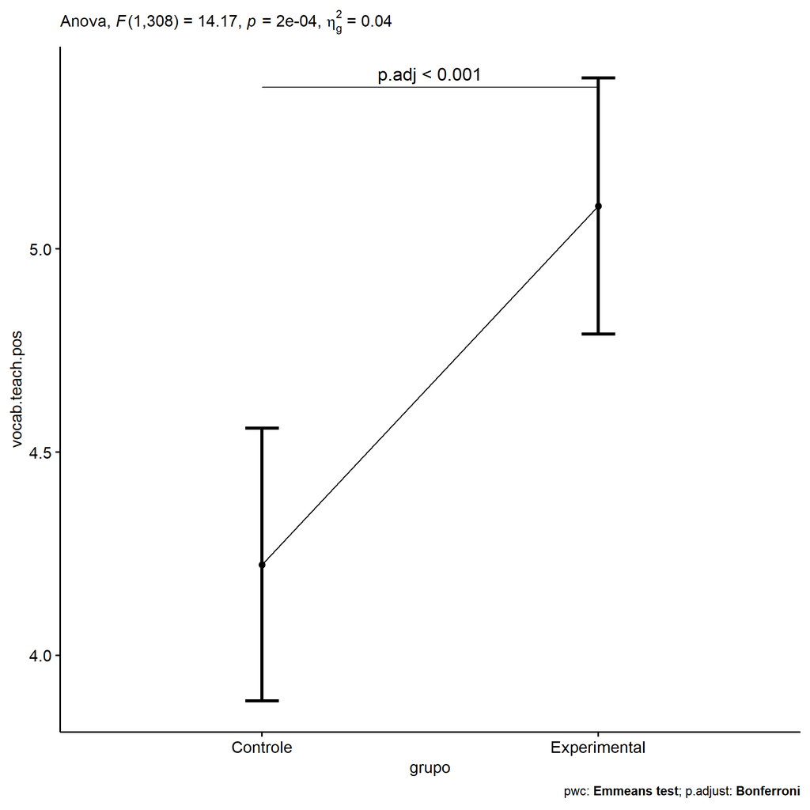

```r
if (!is.null(nrow(plots[["grupo"]]$data)))
  plots[["grupo"]] + ggplot2::scale_color_manual(values = color[["grupo"]])
```

```r
plots <- oneWayAncovaBoxPlots(
  wdat, "vocab.teach.pos", "grupo", aov, pwc, covar = "vocab.teach.pre",
  theme = "classic", color = color[["grupo"]],
  subtitle = which(aov$Effect == "grupo"))
```

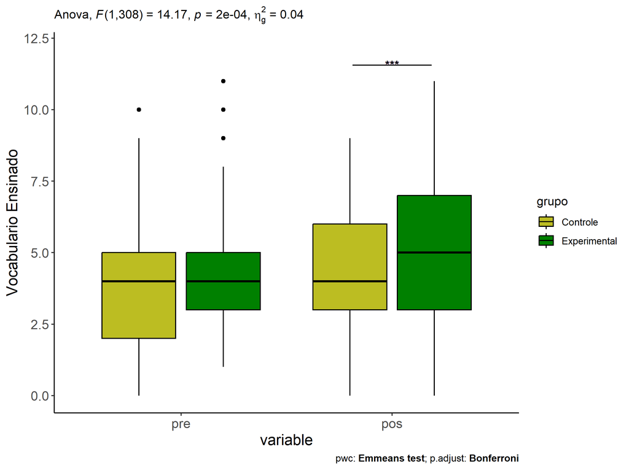

```r
if (length(unique(wdat[["grupo"]])) > 1)
  plots[["grupo"]] + ggplot2::ylab("Vocabulario Ensinado") + ggplot2::scale_x_discrete(labels=c('pre', 'pos'))
```

```r
if (length(unique(wdat.long[["grupo"]])) > 1)
  plots <- oneWayAncovaBoxPlots(
    wdat.long, "vocab.teach", "grupo", aov, pwc.long, pre.post = "time",
    theme = "classic", color = color$prepost)
```

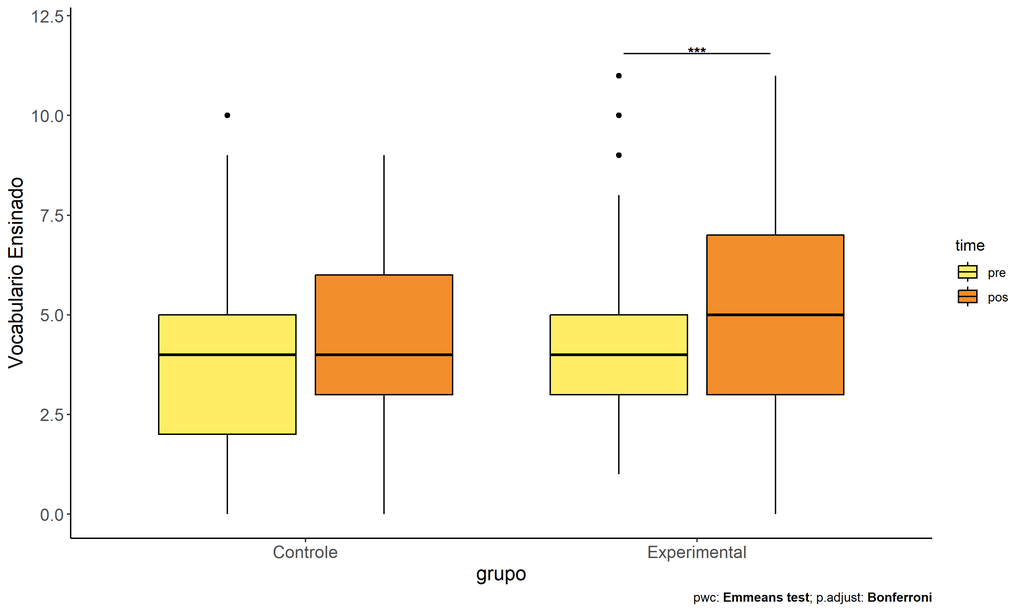

```r
if (length(unique(wdat.long[["grupo"]])) > 1)
  plots[["grupo"]] + ggplot2::ylab("Vocabulario Ensinado")
```

### Checking linearity assumption

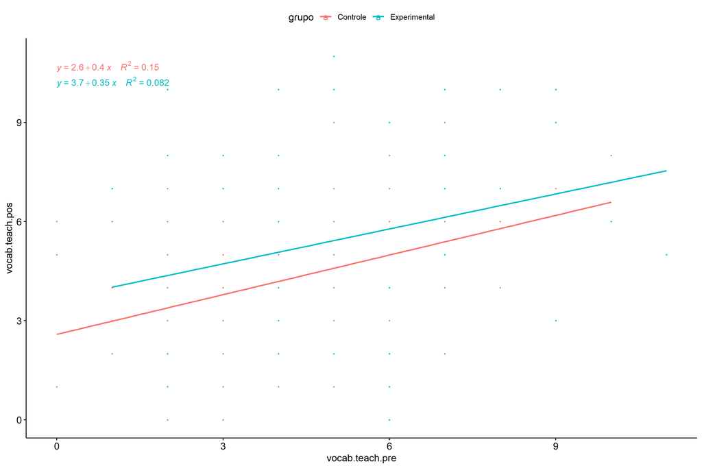

```r
ggscatter(wdat, x = "vocab.teach.pre", y = "vocab.teach.pos", size = 0.5,
          color = "grupo", add = "reg.line")+
  stat_regline_equation(
    aes(label =  paste(..eq.label.., ..rr.label.., sep = "~~~~"), color = grupo)
  )
```

### Checking normality and homogeneity

```r
res <- augment(lm(vocab.teach.pos ~ vocab.teach.pre + grupo, data = wdat))
```

```r
shapiro_test(res$.resid)
```

```
## # A tibble: 1 × 3
##   variable   statistic p.value
##   <chr>          <dbl>   <dbl>
## 1 res$.resid     0.994   0.209
```

```r
levene_test(res, .resid ~ grupo)
```

```
## # A tibble: 1 × 4
##     df1   df2 statistic       p
##   <int> <int>     <dbl>   <dbl>
## 1     1   309      10.2 0.00159
```

# ANCOVA and Pairwise for two factors **grupo:Sexo**

## Without remove non-normal data

```r
pdat = remove_group_data(dat[!is.na(dat[["grupo"]]) & !is.na(dat[["Sexo"]]),], "vocab.teach.pos", c("grupo","Sexo"))

pdat.long <- rbind(pdat[,c("id","grupo","Sexo")], pdat[,c("id","grupo","Sexo")])
pdat.long[["time"]] <- c(rep("pre", nrow(pdat)), rep("pos", nrow(pdat)))
pdat.long[["time"]] <- factor(pdat.long[["time"]], c("pre","pos"))
pdat.long[["vocab.teach"]] <- c(pdat[["vocab.teach.pre"]], pdat[["vocab.teach.pos"]])

aov = anova_test(pdat, vocab.teach.pos ~ vocab.teach.pre + grupo*Sexo)
laov[["grupo:Sexo"]] <- get_anova_table(aov)
```

```r
pwcs <- list()
pwcs[["Sexo"]] <- emmeans_test(
  group_by(pdat, grupo), vocab.teach.pos ~ Sexo,
  covariate = vocab.teach.pre, p.adjust.method = "bonferroni")
pwcs[["grupo"]] <- emmeans_test(
  group_by(pdat, Sexo), vocab.teach.pos ~ grupo,
  covariate = vocab.teach.pre, p.adjust.method = "bonferroni")

pwc <- plyr::rbind.fill(pwcs[["grupo"]], pwcs[["Sexo"]])
pwc <- pwc[,c("grupo","Sexo", colnames(pwc)[!colnames(pwc) %in% c("grupo","Sexo")])]
```

```r
pwc.long <- emmeans_test(dplyr::group_by_at(pdat.long, c("grupo","Sexo")),
                         vocab.teach ~ time,
                         p.adjust.method = "bonferroni")
lpwc[["grupo:Sexo"]] <- plyr::rbind.fill(pwc, pwc.long)
```

```r
ds <- get.descriptives(pdat, "vocab.teach.pos", c("grupo","Sexo"), covar = "vocab.teach.pre")
ds <- merge(ds[ds$variable != "vocab.teach.pre",],
            ds[ds$variable == "vocab.teach.pre", !colnames(ds) %in% c("variable")],
            by = c("grupo","Sexo"), all.x = T, suffixes = c("", ".vocab.teach.pre"))
ds <- merge(get_emmeans(pwcs[["grupo"]]), ds, by = c("grupo","Sexo"), suffixes = c(".emms", ""))
ds <- ds[,c("grupo","Sexo","n","mean.vocab.teach.pre","se.vocab.teach.pre","mean","se","emmean","se.emms")]

colnames(ds) <- c("grupo","Sexo", "N", paste0(c("M","SE")," (pre)"),
                  paste0(c("M","SE"), " (unadj)"), paste0(c("M", "SE"), " (adj)"))

lemms[["grupo:Sexo"]] <- ds
```

## Computing ANCOVA and PairWise After removing non-normal data (OK)

```r
wdat = pdat

res = residuals(lm(vocab.teach.pos ~ vocab.teach.pre + grupo*Sexo, data = wdat))
non.normal = getNonNormal(res, wdat$id, plimit = 0.05)

wdat = wdat[!wdat$id %in% non.normal,]

wdat.long <- rbind(wdat[,c("id","grupo","Sexo")], wdat[,c("id","grupo","Sexo")])
wdat.long[["time"]] <- c(rep("pre", nrow(wdat)), rep("pos", nrow(wdat)))
wdat.long[["time"]] <- factor(wdat.long[["time"]], c("pre","pos"))
wdat.long[["vocab.teach"]] <- c(wdat[["vocab.teach.pre"]], wdat[["vocab.teach.pos"]])


ldat[["grupo:Sexo"]] = wdat

(non.normal)
```

```r
aov = anova_test(wdat, vocab.teach.pos ~ vocab.teach.pre + grupo*Sexo)
laov[["grupo:Sexo"]] <- merge(get_anova_table(aov), laov[["grupo:Sexo"]], by="Effect", suffixes = c("","'"))

(df = get_anova_table(aov))
```

```
## ANOVA Table (type II tests)
##
##            Effect DFn DFd      F        p p<.05   ges
## 1 vocab.teach.pre   1 306 36.689 4.06e-09     * 0.107
## 2           grupo   1 306 12.667 4.31e-04     * 0.040
## 3            Sexo   1 306  7.229 8.00e-03     * 0.023
## 4      grupo:Sexo   1 306  0.455 5.00e-01       0.001
```

| Effect | DFn | DFd | F | p | p<.05 | ges |
| --- | --- | --- | --- | --- | --- | --- |
| vocab.teach.pre | 1 | 306 | 36.689 | 0.000 | * | 0.107 |
| grupo | 1 | 306 | 12.667 | 0.000 | * | 0.040 |
| Sexo | 1 | 306 | 7.229 | 0.008 | * | 0.023 |
| grupo:Sexo | 1 | 306 | 0.455 | 0.500 |  | 0.001 |

```r
pwcs <- list()
pwcs[["Sexo"]] <- emmeans_test(
  group_by(wdat, grupo), vocab.teach.pos ~ Sexo,
  covariate = vocab.teach.pre, p.adjust.method = "bonferroni")
pwcs[["grupo"]] <- emmeans_test(
  group_by(wdat, Sexo), vocab.teach.pos ~ grupo,
  covariate = vocab.teach.pre, p.adjust.method = "bonferroni")

pwc <- plyr::rbind.fill(pwcs[["grupo"]], pwcs[["Sexo"]])
pwc <- pwc[,c("grupo","Sexo", colnames(pwc)[!colnames(pwc) %in% c("grupo","Sexo")])]
```

| grupo | Sexo | term | .y. | group1 | group2 | df | statistic | p | p.adj | p.adj.signif |
| --- | --- | --- | --- | --- | --- | --- | --- | --- | --- | --- |
|  | F | vocab.teach.pre*grupo | vocab.teach.pos | Controle | Experimental | 306 | -2.971 | 0.003 | 0.003 | ** |
|  | M | vocab.teach.pre*grupo | vocab.teach.pos | Controle | Experimental | 306 | -2.082 | 0.038 | 0.038 | * |
| Controle |  | vocab.teach.pre*Sexo | vocab.teach.pos | F | M | 306 | 1.346 | 0.179 | 0.179 | ns |
| Experimental |  | vocab.teach.pre*Sexo | vocab.teach.pos | F | M | 306 | 2.424 | 0.016 | 0.016 | * |

```r
pwc.long <- emmeans_test(dplyr::group_by_at(wdat.long, c("grupo","Sexo")),
                         vocab.teach ~ time,
                         p.adjust.method = "bonferroni")
lpwc[["grupo:Sexo"]] <- merge(plyr::rbind.fill(pwc, pwc.long), lpwc[["grupo:Sexo"]], by=c("grupo","Sexo","term",".y.","group1","group2"), suffixes = c("","'"))
```

| grupo | Sexo | term | .y. | group1 | group2 | df | statistic | p | p.adj | p.adj.signif |
| --- | --- | --- | --- | --- | --- | --- | --- | --- | --- | --- |
| Controle | F | time | vocab.teach | pre | pos | 614 | -1.122 | 0.262 | 0.262 | ns |
| Controle | M | time | vocab.teach | pre | pos | 614 | -0.309 | 0.757 | 0.757 | ns |
| Experimental | F | time | vocab.teach | pre | pos | 614 | -4.080 | 0.000 | 0.000 | **** |
| Experimental | M | time | vocab.teach | pre | pos | 614 | -1.586 | 0.113 | 0.113 | ns |

```r
ds <- get.descriptives(wdat, "vocab.teach.pos", c("grupo","Sexo"), covar = "vocab.teach.pre")
ds <- merge(ds[ds$variable != "vocab.teach.pre",],
            ds[ds$variable == "vocab.teach.pre", !colnames(ds) %in% c("variable")],
            by = c("grupo","Sexo"), all.x = T, suffixes = c("", ".vocab.teach.pre"))
ds <- merge(get_emmeans(pwcs[["grupo"]]), ds, by = c("grupo","Sexo"), suffixes = c(".emms", ""))
ds <- ds[,c("grupo","Sexo","n","mean.vocab.teach.pre","se.vocab.teach.pre","mean","se","emmean","se.emms")]

colnames(ds) <- c("grupo","Sexo", "N", paste0(c("M","SE")," (pre)"),
                  paste0(c("M","SE"), " (unadj)"), paste0(c("M", "SE"), " (adj)"))

lemms[["grupo:Sexo"]] <- merge(ds, lemms[["grupo:Sexo"]], by=c("grupo","Sexo"), suffixes = c("","'"))
```

| grupo | Sexo | N | M (pre) | SE (pre) | M (unadj) | SE (unadj) | M (adj) | SE (adj) |
| --- | --- | --- | --- | --- | --- | --- | --- | --- |
| Controle | F | 65 | 4.062 | 0.232 | 4.462 | 0.246 | 4.476 | 0.253 |
| Controle | M | 81 | 3.815 | 0.215 | 3.914 | 0.212 | 4.019 | 0.227 |
| Experimental | F | 88 | 4.284 | 0.206 | 5.534 | 0.235 | 5.466 | 0.217 |
| Experimental | M | 77 | 4.221 | 0.214 | 4.740 | 0.278 | 4.696 | 0.232 |

### Plots for ancova

```r
plots <- twoWayAncovaPlots(
  wdat, "vocab.teach.pos", c("grupo","Sexo"), aov, pwcs, addParam = c("mean_se"),
  font.label.size=10, step.increase=0.05, p.label="p.adj",
  subtitle = which(aov$Effect == "grupo:Sexo"))
```

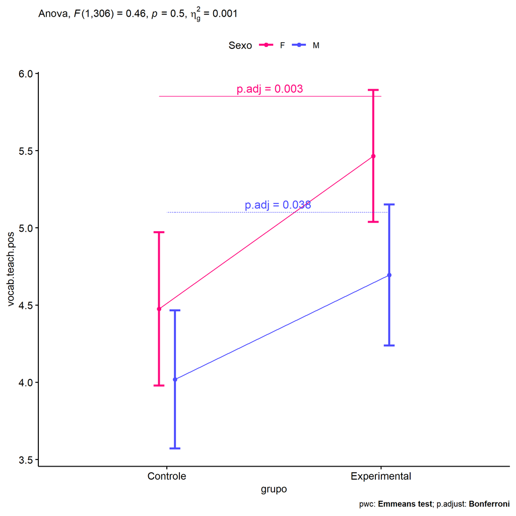

```r
if (!is.null(plots[["grupo"]]))
  plots[["grupo"]] + ggplot2::scale_color_manual(values = color[["Sexo"]])
```

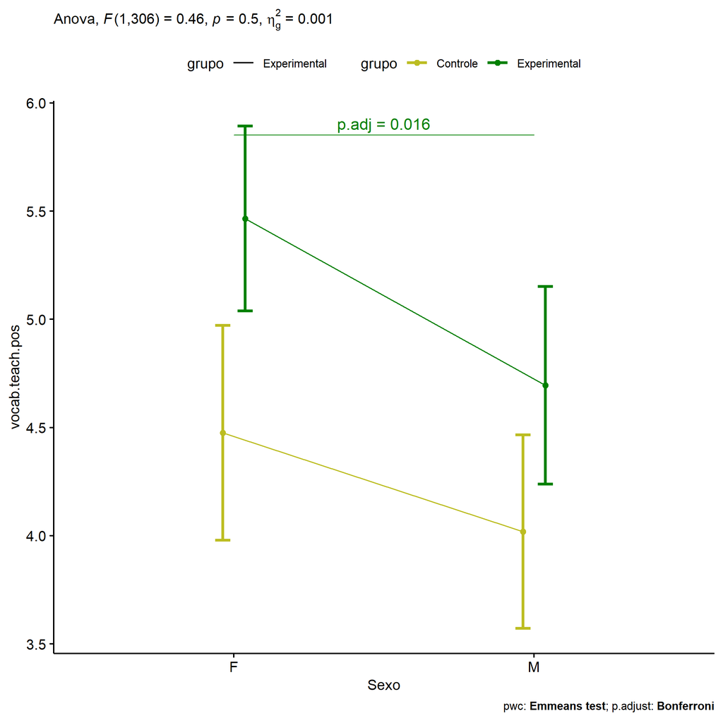

```r
if (!is.null(plots[["Sexo"]]))
  plots[["Sexo"]] + ggplot2::scale_color_manual(values = color[["grupo"]])
```

```r
plots <- twoWayAncovaBoxPlots(
  wdat, "vocab.teach.pos", c("grupo","Sexo"), aov, pwcs, covar = "vocab.teach.pre",
  theme = "classic", color = color[["grupo:Sexo"]],
  subtitle = which(aov$Effect == "grupo:Sexo"))
```

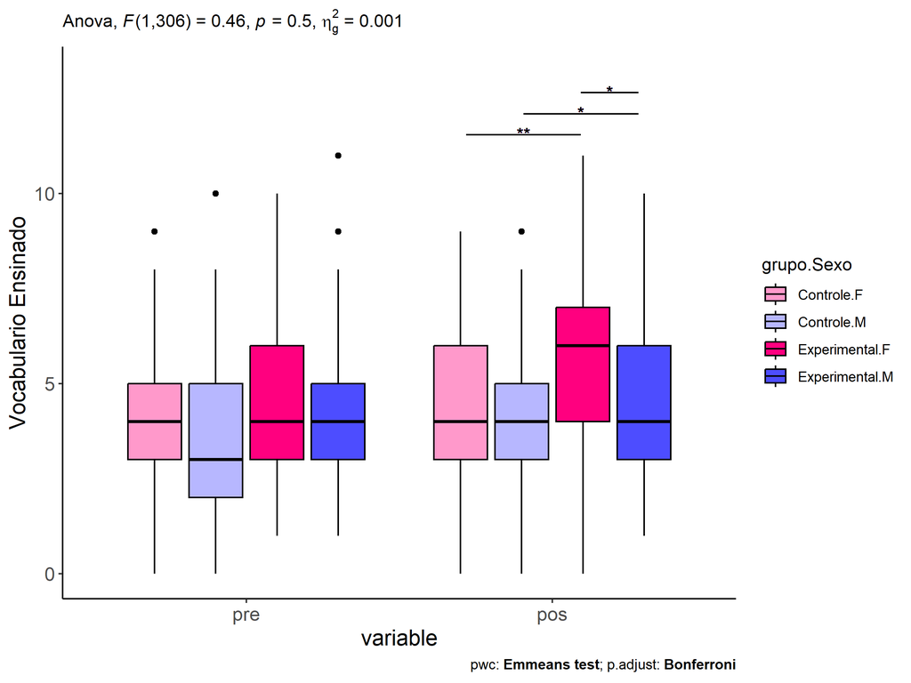

```r
plots[["grupo:Sexo"]] + ggplot2::ylab("Vocabulario Ensinado") + ggplot2::scale_x_discrete(labels=c('pre', 'pos'))
```

```r
plots <- twoWayAncovaBoxPlots(
  wdat.long, "vocab.teach", c("grupo","Sexo"), aov, pwc.long, pre.post = "time",
  theme = "classic", color = color$prepost)
```

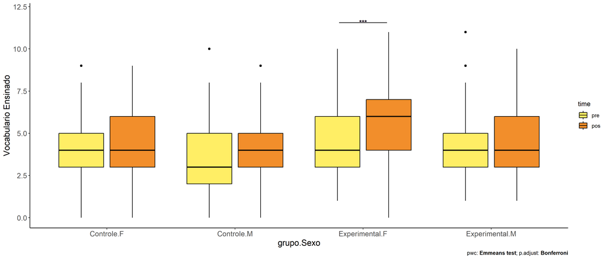

```r
plots[["grupo:Sexo"]] + ggplot2::ylab("Vocabulario Ensinado")
```

### Checking linearity assumption

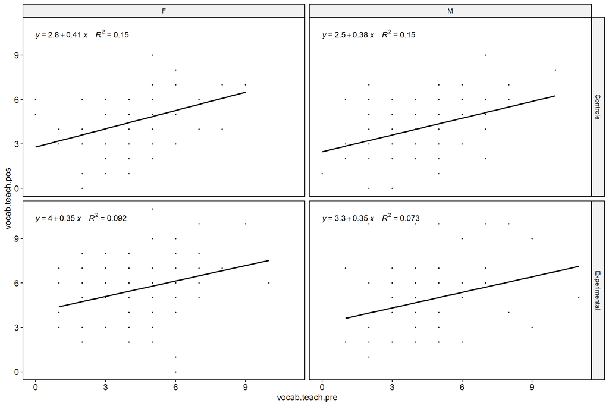

```r
ggscatter(wdat, x = "vocab.teach.pre", y = "vocab.teach.pos", size = 0.5,
          facet.by = c("grupo","Sexo"), add = "reg.line")+
  stat_regline_equation(
    aes(label =  paste(..eq.label.., ..rr.label.., sep = "~~~~"))
  )
```

### Checking normality and homogeneity

```r
res <- augment(lm(vocab.teach.pos ~ vocab.teach.pre + grupo*Sexo, data = wdat))
```

```r
shapiro_test(res$.resid)
```

```
## # A tibble: 1 × 3
##   variable   statistic p.value
##   <chr>          <dbl>   <dbl>
## 1 res$.resid     0.994   0.227
```

```r
levene_test(res, .resid ~ grupo*Sexo)
```

```
## # A tibble: 1 × 4
##     df1   df2 statistic      p
##   <int> <int>     <dbl>  <dbl>
## 1     3   307      2.65 0.0490
```

# ANCOVA and Pairwise for two factors **grupo:Zona**

## Without remove non-normal data

```r
pdat = remove_group_data(dat[!is.na(dat[["grupo"]]) & !is.na(dat[["Zona"]]),], "vocab.teach.pos", c("grupo","Zona"))

pdat.long <- rbind(pdat[,c("id","grupo","Zona")], pdat[,c("id","grupo","Zona")])
pdat.long[["time"]] <- c(rep("pre", nrow(pdat)), rep("pos", nrow(pdat)))
pdat.long[["time"]] <- factor(pdat.long[["time"]], c("pre","pos"))
pdat.long[["vocab.teach"]] <- c(pdat[["vocab.teach.pre"]], pdat[["vocab.teach.pos"]])

aov = anova_test(pdat, vocab.teach.pos ~ vocab.teach.pre + grupo*Zona)
laov[["grupo:Zona"]] <- get_anova_table(aov)
```

```r
pwcs <- list()
pwcs[["Zona"]] <- emmeans_test(
  group_by(pdat, grupo), vocab.teach.pos ~ Zona,
  covariate = vocab.teach.pre, p.adjust.method = "bonferroni")
pwcs[["grupo"]] <- emmeans_test(
  group_by(pdat, Zona), vocab.teach.pos ~ grupo,
  covariate = vocab.teach.pre, p.adjust.method = "bonferroni")

pwc <- plyr::rbind.fill(pwcs[["grupo"]], pwcs[["Zona"]])
pwc <- pwc[,c("grupo","Zona", colnames(pwc)[!colnames(pwc) %in% c("grupo","Zona")])]
```

```r
pwc.long <- emmeans_test(dplyr::group_by_at(pdat.long, c("grupo","Zona")),
                         vocab.teach ~ time,
                         p.adjust.method = "bonferroni")
lpwc[["grupo:Zona"]] <- plyr::rbind.fill(pwc, pwc.long)
```

```r
ds <- get.descriptives(pdat, "vocab.teach.pos", c("grupo","Zona"), covar = "vocab.teach.pre")
ds <- merge(ds[ds$variable != "vocab.teach.pre",],
            ds[ds$variable == "vocab.teach.pre", !colnames(ds) %in% c("variable")],
            by = c("grupo","Zona"), all.x = T, suffixes = c("", ".vocab.teach.pre"))
ds <- merge(get_emmeans(pwcs[["grupo"]]), ds, by = c("grupo","Zona"), suffixes = c(".emms", ""))
ds <- ds[,c("grupo","Zona","n","mean.vocab.teach.pre","se.vocab.teach.pre","mean","se","emmean","se.emms")]

colnames(ds) <- c("grupo","Zona", "N", paste0(c("M","SE")," (pre)"),
                  paste0(c("M","SE"), " (unadj)"), paste0(c("M", "SE"), " (adj)"))

lemms[["grupo:Zona"]] <- ds
```

## Computing ANCOVA and PairWise After removing non-normal data (OK)

```r
wdat = pdat

res = residuals(lm(vocab.teach.pos ~ vocab.teach.pre + grupo*Zona, data = wdat))
non.normal = getNonNormal(res, wdat$id, plimit = 0.05)

wdat = wdat[!wdat$id %in% non.normal,]

wdat.long <- rbind(wdat[,c("id","grupo","Zona")], wdat[,c("id","grupo","Zona")])
wdat.long[["time"]] <- c(rep("pre", nrow(wdat)), rep("pos", nrow(wdat)))
wdat.long[["time"]] <- factor(wdat.long[["time"]], c("pre","pos"))
wdat.long[["vocab.teach"]] <- c(wdat[["vocab.teach.pre"]], wdat[["vocab.teach.pos"]])


ldat[["grupo:Zona"]] = wdat

(non.normal)
```

```r
aov = anova_test(wdat, vocab.teach.pos ~ vocab.teach.pre + grupo*Zona)
laov[["grupo:Zona"]] <- merge(get_anova_table(aov), laov[["grupo:Zona"]], by="Effect", suffixes = c("","'"))

(df = get_anova_table(aov))
```

```
## ANOVA Table (type II tests)
##
##            Effect DFn DFd      F        p p<.05      ges
## 1 vocab.teach.pre   1 243 34.761 1.24e-08     * 0.125000
## 2           grupo   1 243  8.616 4.00e-03     * 0.034000
## 3            Zona   1 243  1.135 2.88e-01       0.005000
## 4      grupo:Zona   1 243  0.066 7.97e-01       0.000272
```

| Effect | DFn | DFd | F | p | p<.05 | ges |
| --- | --- | --- | --- | --- | --- | --- |
| vocab.teach.pre | 1 | 243 | 34.761 | 0.000 | * | 0.125 |
| grupo | 1 | 243 | 8.616 | 0.004 | * | 0.034 |
| Zona | 1 | 243 | 1.135 | 0.288 |  | 0.005 |
| grupo:Zona | 1 | 243 | 0.066 | 0.797 |  | 0.000 |

```r
pwcs <- list()
pwcs[["Zona"]] <- emmeans_test(
  group_by(wdat, grupo), vocab.teach.pos ~ Zona,
  covariate = vocab.teach.pre, p.adjust.method = "bonferroni")
pwcs[["grupo"]] <- emmeans_test(
  group_by(wdat, Zona), vocab.teach.pos ~ grupo,
  covariate = vocab.teach.pre, p.adjust.method = "bonferroni")

pwc <- plyr::rbind.fill(pwcs[["grupo"]], pwcs[["Zona"]])
pwc <- pwc[,c("grupo","Zona", colnames(pwc)[!colnames(pwc) %in% c("grupo","Zona")])]
```

| grupo | Zona | term | .y. | group1 | group2 | df | statistic | p | p.adj | p.adj.signif |
| --- | --- | --- | --- | --- | --- | --- | --- | --- | --- | --- |
|  | Rural | vocab.teach.pre*grupo | vocab.teach.pos | Controle | Experimental | 243 | -2.654 | 0.008 | 0.008 | ** |
|  | Urbana | vocab.teach.pre*grupo | vocab.teach.pos | Controle | Experimental | 243 | -1.282 | 0.201 | 0.201 | ns |
| Controle |  | vocab.teach.pre*Zona | vocab.teach.pos | Rural | Urbana | 243 | -0.907 | 0.365 | 0.365 | ns |
| Experimental |  | vocab.teach.pre*Zona | vocab.teach.pos | Rural | Urbana | 243 | -0.614 | 0.540 | 0.540 | ns |

```r
pwc.long <- emmeans_test(dplyr::group_by_at(wdat.long, c("grupo","Zona")),
                         vocab.teach ~ time,
                         p.adjust.method = "bonferroni")
lpwc[["grupo:Zona"]] <- merge(plyr::rbind.fill(pwc, pwc.long), lpwc[["grupo:Zona"]], by=c("grupo","Zona","term",".y.","group1","group2"), suffixes = c("","'"))
```

| grupo | Zona | term | .y. | group1 | group2 | df | statistic | p | p.adj | p.adj.signif |
| --- | --- | --- | --- | --- | --- | --- | --- | --- | --- | --- |
| Controle | Rural | time | vocab.teach | pre | pos | 488 | -0.381 | 0.703 | 0.703 | ns |
| Controle | Urbana | time | vocab.teach | pre | pos | 488 | -1.033 | 0.302 | 0.302 | ns |
| Experimental | Rural | time | vocab.teach | pre | pos | 488 | -2.741 | 0.006 | 0.006 | ** |
| Experimental | Urbana | time | vocab.teach | pre | pos | 488 | -1.994 | 0.047 | 0.047 | * |

```r
ds <- get.descriptives(wdat, "vocab.teach.pos", c("grupo","Zona"), covar = "vocab.teach.pre")
ds <- merge(ds[ds$variable != "vocab.teach.pre",],
            ds[ds$variable == "vocab.teach.pre", !colnames(ds) %in% c("variable")],
            by = c("grupo","Zona"), all.x = T, suffixes = c("", ".vocab.teach.pre"))
ds <- merge(get_emmeans(pwcs[["grupo"]]), ds, by = c("grupo","Zona"), suffixes = c(".emms", ""))
ds <- ds[,c("grupo","Zona","n","mean.vocab.teach.pre","se.vocab.teach.pre","mean","se","emmean","se.emms")]

colnames(ds) <- c("grupo","Zona", "N", paste0(c("M","SE")," (pre)"),
                  paste0(c("M","SE"), " (unadj)"), paste0(c("M", "SE"), " (adj)"))

lemms[["grupo:Zona"]] <- merge(ds, lemms[["grupo:Zona"]], by=c("grupo","Zona"), suffixes = c("","'"))
```

| grupo | Zona | N | M (pre) | SE (pre) | M (unadj) | SE (unadj) | M (adj) | SE (adj) |
| --- | --- | --- | --- | --- | --- | --- | --- | --- |
| Controle | Rural | 97 | 4.072 | 0.206 | 4.186 | 0.200 | 4.207 | 0.204 |
| Controle | Urbana | 28 | 3.964 | 0.339 | 4.536 | 0.351 | 4.598 | 0.380 |
| Experimental | Rural | 85 | 4.129 | 0.216 | 5.000 | 0.250 | 5.000 | 0.218 |
| Experimental | Urbana | 38 | 4.395 | 0.330 | 5.342 | 0.387 | 5.241 | 0.327 |

### Plots for ancova

```r
plots <- twoWayAncovaPlots(
  wdat, "vocab.teach.pos", c("grupo","Zona"), aov, pwcs, addParam = c("mean_se"),
  font.label.size=10, step.increase=0.05, p.label="p.adj",
  subtitle = which(aov$Effect == "grupo:Zona"))
```

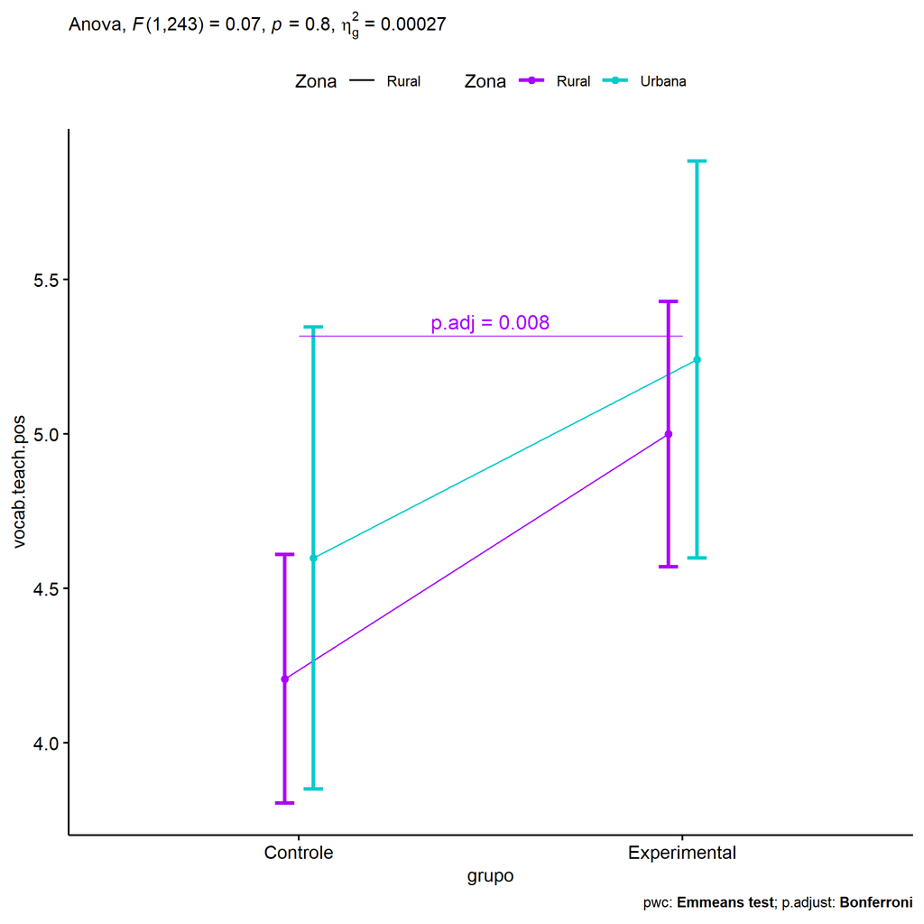

```r
if (!is.null(plots[["grupo"]]))
  plots[["grupo"]] + ggplot2::scale_color_manual(values = color[["Zona"]])
```

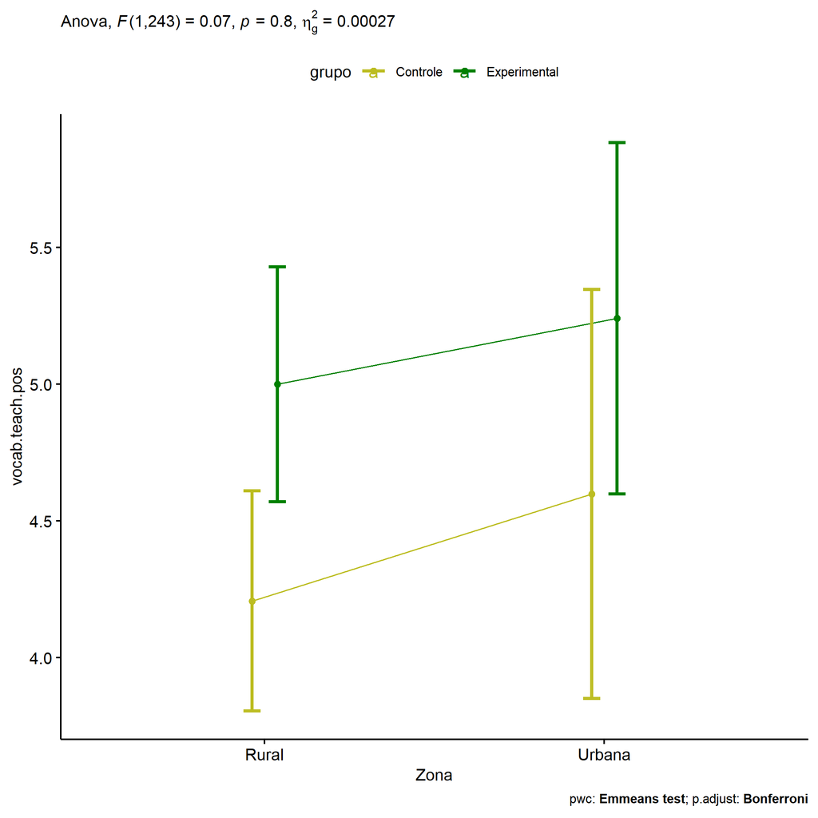

```r
if (!is.null(plots[["Zona"]]))
  plots[["Zona"]] + ggplot2::scale_color_manual(values = color[["grupo"]])
```

```r
plots <- twoWayAncovaBoxPlots(
  wdat, "vocab.teach.pos", c("grupo","Zona"), aov, pwcs, covar = "vocab.teach.pre",
  theme = "classic", color = color[["grupo:Zona"]],
  subtitle = which(aov$Effect == "grupo:Zona"))
```

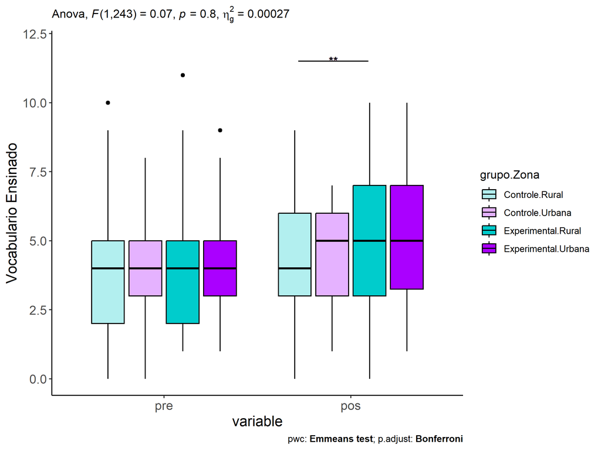

```r
plots[["grupo:Zona"]] + ggplot2::ylab("Vocabulario Ensinado") + ggplot2::scale_x_discrete(labels=c('pre', 'pos'))
```

```r
plots <- twoWayAncovaBoxPlots(
  wdat.long, "vocab.teach", c("grupo","Zona"), aov, pwc.long, pre.post = "time",
  theme = "classic", color = color$prepost)
```

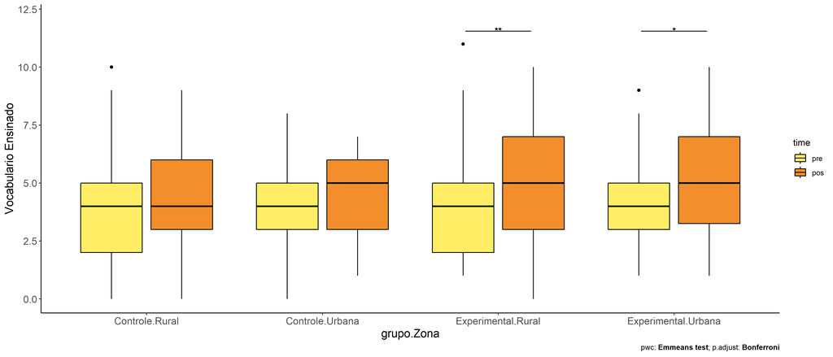

```r
plots[["grupo:Zona"]] + ggplot2::ylab("Vocabulario Ensinado")
```

### Checking linearity assumption

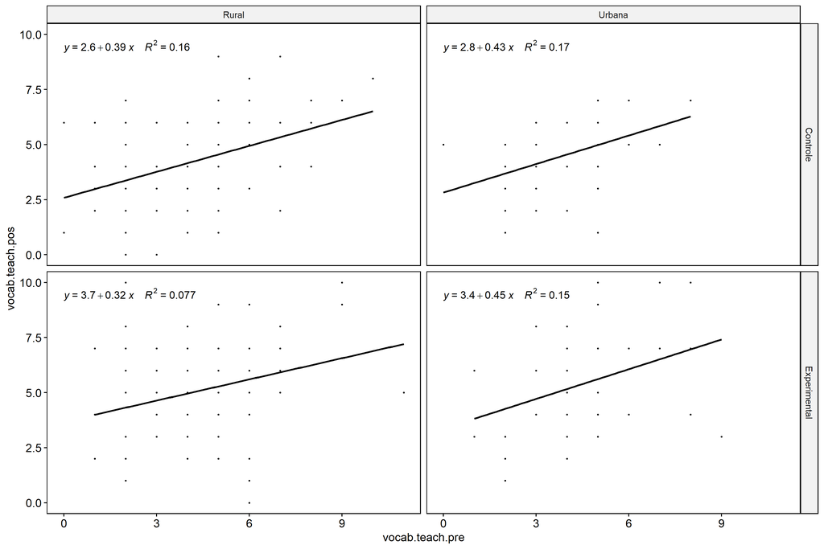

```r
ggscatter(wdat, x = "vocab.teach.pre", y = "vocab.teach.pos", size = 0.5,
          facet.by = c("grupo","Zona"), add = "reg.line")+
  stat_regline_equation(
    aes(label =  paste(..eq.label.., ..rr.label.., sep = "~~~~"))
  )
```

### Checking normality and homogeneity

```r
res <- augment(lm(vocab.teach.pos ~ vocab.teach.pre + grupo*Zona, data = wdat))
```

```r
shapiro_test(res$.resid)
```

```
## # A tibble: 1 × 3
##   variable   statistic p.value
##   <chr>          <dbl>   <dbl>
## 1 res$.resid     0.995   0.556
```

```r
levene_test(res, .resid ~ grupo*Zona)
```

```
## # A tibble: 1 × 4
##     df1   df2 statistic      p
##   <int> <int>     <dbl>  <dbl>
## 1     3   244      3.14 0.0259
```

# ANCOVA and Pairwise for two factors **grupo:Cor.Raca**

## Without remove non-normal data

```r
pdat = remove_group_data(dat[!is.na(dat[["grupo"]]) & !is.na(dat[["Cor.Raca"]]),], "vocab.teach.pos", c("grupo","Cor.Raca"))
pdat.long <- rbind(pdat[,c("id","grupo","Cor.Raca")], pdat[,c("id","grupo","Cor.Raca")])
pdat.long[["time"]] <- c(rep("pre", nrow(pdat)), rep("pos", nrow(pdat)))
pdat.long[["time"]] <- factor(pdat.long[["time"]], c("pre","pos"))
pdat.long[["vocab.teach"]] <- c(pdat[["vocab.teach.pre"]], pdat[["vocab.teach.pos"]])

aov = anova_test(pdat, vocab.teach.pos ~ vocab.teach.pre + grupo*Cor.Raca)
laov[["grupo:Cor.Raca"]] <- get_anova_table(aov)
```

```r
pwcs <- list()
pwcs[["Cor.Raca"]] <- emmeans_test(
  group_by(pdat, grupo), vocab.teach.pos ~ Cor.Raca,
  covariate = vocab.teach.pre, p.adjust.method = "bonferroni")
pwcs[["grupo"]] <- emmeans_test(
  group_by(pdat, Cor.Raca), vocab.teach.pos ~ grupo,
  covariate = vocab.teach.pre, p.adjust.method = "bonferroni")

pwc <- plyr::rbind.fill(pwcs[["grupo"]], pwcs[["Cor.Raca"]])
pwc <- pwc[,c("grupo","Cor.Raca", colnames(pwc)[!colnames(pwc) %in% c("grupo","Cor.Raca")])]
```

```r
pwc.long <- emmeans_test(dplyr::group_by_at(pdat.long, c("grupo","Cor.Raca")),
                         vocab.teach ~ time,
                         p.adjust.method = "bonferroni")
lpwc[["grupo:Cor.Raca"]] <- plyr::rbind.fill(pwc, pwc.long)
```

```r
ds <- get.descriptives(pdat, "vocab.teach.pos", c("grupo","Cor.Raca"), covar = "vocab.teach.pre")
ds <- merge(ds[ds$variable != "vocab.teach.pre",],
            ds[ds$variable == "vocab.teach.pre", !colnames(ds) %in% c("variable")],
            by = c("grupo","Cor.Raca"), all.x = T, suffixes = c("", ".vocab.teach.pre"))
ds <- merge(get_emmeans(pwcs[["grupo"]]), ds, by = c("grupo","Cor.Raca"), suffixes = c(".emms", ""))
ds <- ds[,c("grupo","Cor.Raca","n","mean.vocab.teach.pre","se.vocab.teach.pre","mean","se","emmean","se.emms")]

colnames(ds) <- c("grupo","Cor.Raca", "N", paste0(c("M","SE")," (pre)"),
                  paste0(c("M","SE"), " (unadj)"), paste0(c("M", "SE"), " (adj)"))

lemms[["grupo:Cor.Raca"]] <- ds
```

## Computing ANCOVA and PairWise After removing non-normal data (OK)

```r
wdat = pdat

res = residuals(lm(vocab.teach.pos ~ vocab.teach.pre + grupo*Cor.Raca, data = wdat))
non.normal = getNonNormal(res, wdat$id, plimit = 0.05)

wdat = wdat[!wdat$id %in% non.normal,]

wdat.long <- rbind(wdat[,c("id","grupo","Cor.Raca")], wdat[,c("id","grupo","Cor.Raca")])
wdat.long[["time"]] <- c(rep("pre", nrow(wdat)), rep("pos", nrow(wdat)))
wdat.long[["time"]] <- factor(wdat.long[["time"]], c("pre","pos"))
wdat.long[["vocab.teach"]] <- c(wdat[["vocab.teach.pre"]], wdat[["vocab.teach.pos"]])


ldat[["grupo:Cor.Raca"]] = wdat

(non.normal)
```

```r
aov = anova_test(wdat, vocab.teach.pos ~ vocab.teach.pre + grupo*Cor.Raca)
laov[["grupo:Cor.Raca"]] <- merge(get_anova_table(aov), laov[["grupo:Cor.Raca"]], by="Effect", suffixes = c("","'"))

(df = get_anova_table(aov))
```

```
## ANOVA Table (type II tests)
##
##            Effect DFn DFd      F        p p<.05   ges
## 1 vocab.teach.pre   1 133 28.784 3.49e-07     * 0.178
## 2           grupo   1 133  1.749 1.88e-01       0.013
## 3        Cor.Raca   2 133  0.246 7.82e-01       0.004
## 4  grupo:Cor.Raca   1 133  1.244 2.67e-01       0.009
```

| Effect | DFn | DFd | F | p | p<.05 | ges |
| --- | --- | --- | --- | --- | --- | --- |
| vocab.teach.pre | 1 | 133 | 28.784 | 0.000 | * | 0.178 |
| grupo | 1 | 133 | 1.749 | 0.188 |  | 0.013 |
| Cor.Raca | 2 | 133 | 0.246 | 0.782 |  | 0.004 |
| grupo:Cor.Raca | 1 | 133 | 1.244 | 0.267 |  | 0.009 |

```r
pwcs <- list()
pwcs[["Cor.Raca"]] <- emmeans_test(
  group_by(wdat, grupo), vocab.teach.pos ~ Cor.Raca,
  covariate = vocab.teach.pre, p.adjust.method = "bonferroni")
pwcs[["grupo"]] <- emmeans_test(
  group_by(wdat, Cor.Raca), vocab.teach.pos ~ grupo,
  covariate = vocab.teach.pre, p.adjust.method = "bonferroni")

pwc <- plyr::rbind.fill(pwcs[["grupo"]], pwcs[["Cor.Raca"]])
pwc <- pwc[,c("grupo","Cor.Raca", colnames(pwc)[!colnames(pwc) %in% c("grupo","Cor.Raca")])]
```

| grupo | Cor.Raca | term | .y. | group1 | group2 | df | statistic | p | p.adj | p.adj.signif |
| --- | --- | --- | --- | --- | --- | --- | --- | --- | --- | --- |
|  | Branca | vocab.teach.pre*grupo | vocab.teach.pos | Controle | Experimental | 133 | 0.189 | 0.851 | 0.851 | ns |
|  | Indígena | vocab.teach.pre*grupo | vocab.teach.pos | Controle | Experimental |  |  |  |  |  |
|  | Parda | vocab.teach.pre*grupo | vocab.teach.pos | Controle | Experimental | 133 | -1.720 | 0.088 | 0.088 | ns |
| Controle |  | vocab.teach.pre*Cor.Raca | vocab.teach.pos | Branca | Indígena |  |  |  |  |  |
| Controle |  | vocab.teach.pre*Cor.Raca | vocab.teach.pos | Branca | Parda | 133 | 0.251 | 0.802 | 0.802 | ns |
| Controle |  | vocab.teach.pre*Cor.Raca | vocab.teach.pos | Indígena | Parda |  |  |  |  |  |
| Experimental |  | vocab.teach.pre*Cor.Raca | vocab.teach.pos | Branca | Indígena | 133 | -0.690 | 0.491 | 1.000 | ns |
| Experimental |  | vocab.teach.pre*Cor.Raca | vocab.teach.pos | Branca | Parda | 133 | -1.294 | 0.198 | 0.593 | ns |
| Experimental |  | vocab.teach.pre*Cor.Raca | vocab.teach.pos | Indígena | Parda | 133 | -0.359 | 0.720 | 1.000 | ns |

```r
pwc.long <- emmeans_test(dplyr::group_by_at(wdat.long, c("grupo","Cor.Raca")),
                         vocab.teach ~ time,
                         p.adjust.method = "bonferroni")
lpwc[["grupo:Cor.Raca"]] <- merge(plyr::rbind.fill(pwc, pwc.long), lpwc[["grupo:Cor.Raca"]], by=c("grupo","Cor.Raca","term",".y.","group1","group2"), suffixes = c("","'"))
```

| grupo | Cor.Raca | term | .y. | group1 | group2 | df | statistic | p | p.adj | p.adj.signif |
| --- | --- | --- | --- | --- | --- | --- | --- | --- | --- | --- |
| Controle | Branca | time | vocab.teach | pre | pos | 268 | -0.799 | 0.425 | 0.425 | ns |
| Controle | Indígena | time | vocab.teach | pre | pos |  |  |  |  |  |
| Controle | Parda | time | vocab.teach | pre | pos | 268 | -0.578 | 0.564 | 0.564 | ns |
| Experimental | Branca | time | vocab.teach | pre | pos | 268 | 0.161 | 0.873 | 0.873 | ns |
| Experimental | Indígena | time | vocab.teach | pre | pos | 268 | -0.945 | 0.346 | 0.346 | ns |
| Experimental | Parda | time | vocab.teach | pre | pos | 268 | -2.413 | 0.016 | 0.016 | * |

```r
ds <- get.descriptives(wdat, "vocab.teach.pos", c("grupo","Cor.Raca"), covar = "vocab.teach.pre")
ds <- merge(ds[ds$variable != "vocab.teach.pre",],
            ds[ds$variable == "vocab.teach.pre", !colnames(ds) %in% c("variable")],
            by = c("grupo","Cor.Raca"), all.x = T, suffixes = c("", ".vocab.teach.pre"))
ds <- merge(get_emmeans(pwcs[["grupo"]]), ds, by = c("grupo","Cor.Raca"), suffixes = c(".emms", ""))
ds <- ds[,c("grupo","Cor.Raca","n","mean.vocab.teach.pre","se.vocab.teach.pre","mean","se","emmean","se.emms")]

colnames(ds) <- c("grupo","Cor.Raca", "N", paste0(c("M","SE")," (pre)"),
                  paste0(c("M","SE"), " (unadj)"), paste0(c("M", "SE"), " (adj)"))

lemms[["grupo:Cor.Raca"]] <- merge(ds, lemms[["grupo:Cor.Raca"]], by=c("grupo","Cor.Raca"), suffixes = c("","'"))
```

| grupo | Cor.Raca | N | M (pre) | SE (pre) | M (unadj) | SE (unadj) | M (adj) | SE (adj) |
| --- | --- | --- | --- | --- | --- | --- | --- | --- |
| Controle | Branca | 22 | 3.773 | 0.400 | 4.273 | 0.498 | 4.386 | 0.430 |
| Controle | Parda | 42 | 3.976 | 0.336 | 4.238 | 0.323 | 4.253 | 0.311 |
| Experimental | Branca | 18 | 4.722 | 0.441 | 4.611 | 0.584 | 4.264 | 0.479 |
| Experimental | Indígena | 13 | 4.000 | 0.392 | 4.769 | 0.568 | 4.773 | 0.559 |
| Experimental | Parda | 44 | 3.864 | 0.277 | 4.932 | 0.332 | 5.001 | 0.304 |